# Video game sales data exploration

## by Birinder Singh

## Dataset Overview

**1.Name** - Name of each game title.  
**2.Platform** - Name of each platform on which the game was released. All the platforms mentioned in Dataset are as follows. Playstation 2 (PS2), XBox 360 (X360), Playstation 3 (PS3), Computer (PC), XBox (XB), wii (Nintendo Wii), DS (Nintendo Dual Screen), PSP (Playstation Portable), GC (Nintendo Game Cube),PS4 (Playstation 4), GBA (Game Boy Advance), XOne ( XBox One), 3DS (Nintendo Three Dimensional Screen), PS (Playstation), PSV (Playstation Vita), WiiU (Nintendo Wii You) and DC (Sega Dreamcast).  
**3.Year_of_Release** - Year in which the game was released.  
**4.Genre** - The Genre of the game.  
**5.Publisher** - The Company who published the game under their name.  
**6.NA_Sales** - All the game units sold (in millions) in North American region.  
**7.EU_Sales** - All the game units sold (in millions) in European region.  
**8.JP_Sales** - All the game units sold (in millions) in Japan region.  
**9.Other_Sales** - All the game units sold (in millions) in other region.  
**10.Global_Sales**- All the game units sold (in millions) globally.  
**11.Critic_Score**- Score given to games by Metacritic.  
**12.Critic_Count**- Number of critics whole reviewed the game and assigned the score to them.  
**13.User_Score**- Score given to games by Normal Users.  
**14.User_Count**- Number of users/players whole reviewed the game and assigned the score to them.  
**15.Developer**- The developers who developed the game.  
**16.Rating**- There are 7 metrics of Rating which are as:- T (Teen), E (Everyone), M (Mature), E10+ (Everyone above the age of 10), K-A ( Kids to Adults ), RP ( Rating Pending )and AO ( Adults Only ).

## Investigation Overview

> In this exploration analysis, I will explore and establish different relationship amongst various quantitative and qualitative variables. I will witness areas where cause and effect relation will actually work.

### 1. How many games were released in the specific year ?

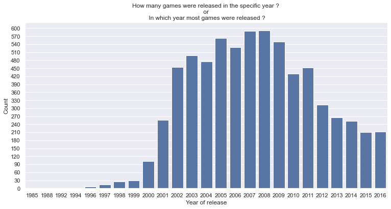

> **INSIGHT-** As we can see the highest bar is above the year 2008, by which we can easily conclude that year 2008 was really a good year of all the gamers around the world. 2008 is in top with 592 games released defeating 2007 (by 2 more games) and 2005 (by 30 more games) and many others.!

### 2. How many games were released for specific Platform ?

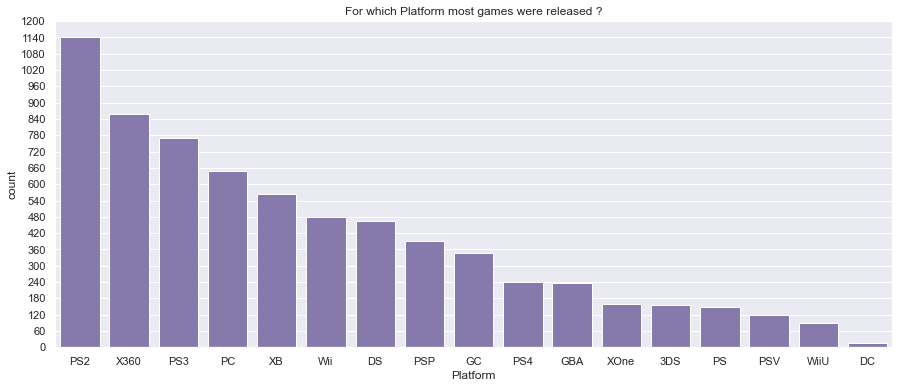

> **INSIGHT-** We all know Playstation 2 ruled the childhood of all the kids and adults of 2000s and 90s respectively, The same way it is ruling the chart right now. Most of the titles were released for PS2, which are 1140. After PS2 there is a huge leap of 282 titles, which make the Xbox 360 'the second' with 868 titles. Only 14 games were released for DC console which make it last in the league of consoles. Since Our database is cropped after cleaning, the results may not actually match the google answers.

### 3. Which Video game genre is most Popular ?

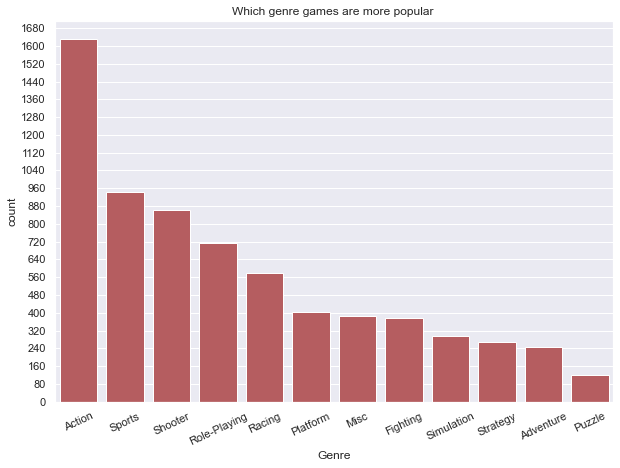

**INSIGHT-** Who doesn't love action. Thats exactly what game publishers and developers thinks while creating a game and deciding its genre. Even I love every game of Action genre. We can even conclude in the bar plot plotted, that most of the games that were released were of Action genre. Only few like puzzles, that's why it is in the bottom of the order. Around 1630 games were of Action genre, and Sports were the second next favorite genre with around 943 games released for it.

### 4. How many games sold most units Globally ?

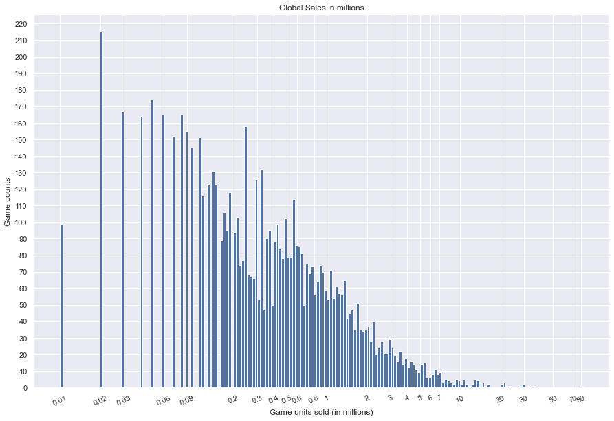

**INSIGHT-** There are 215 titles that were able to hit a mark of 20000 unit sold globally. However there is only 1 game that was most sold and which made up to 82530000 sales globally. You can also see a hike of bars in 0.2-0.3 million units, which also justifies that most of the games were being sold globally between 0.02 and 0.2-0.3 numbers.

### 5. How many games sold most units among different regions ?

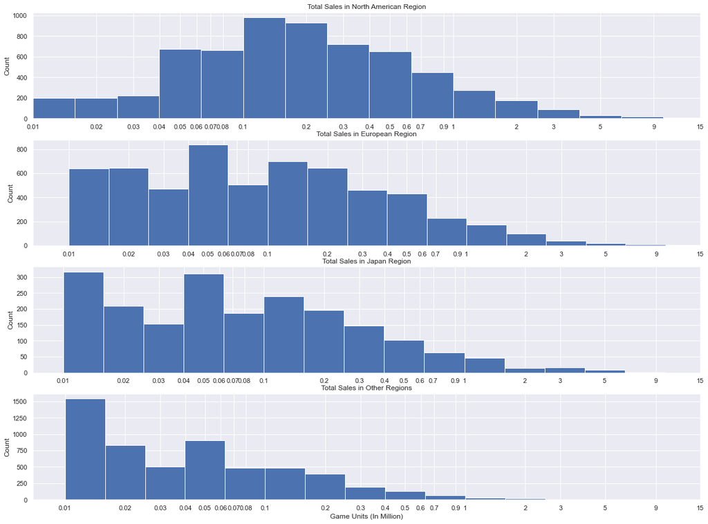

### 6. Which game Rating is more Popular ?

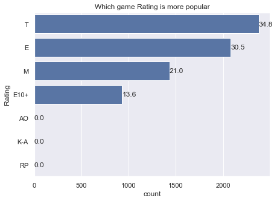

**INSIGHT-** For better understanding I plotted the percentage of specific Rating on that specific bar. As we can see that Games with Teen Rating (T) is more popular, with 34.8% of all the titles, Everyone(E) comes on second with 30.5% of all the titles, Mature (M) comes on third with 21% of all the titles, Everyone above 10 (E10+) comes on fourth with 13.6% of all the titles. Since Rating for RP,AO,and K-A are all 0.01 %, they appear too low or almost NULL.

### 7. Which Critic Score is most common ?

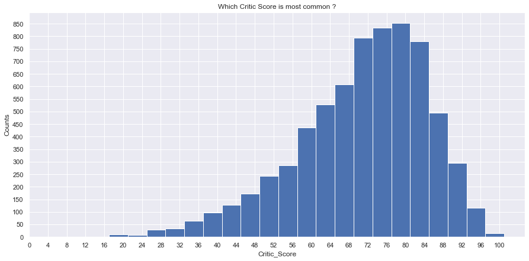

**INSIGHT-** From seeing it's easily understandable that around 850 titles have critic Score between 76-80, which is the highest score amongst all. The most of the games have Critic Score between 68-84. Its actually kind of close to Normal Distribution.

### 8. Top 10 Developers and Publishers.

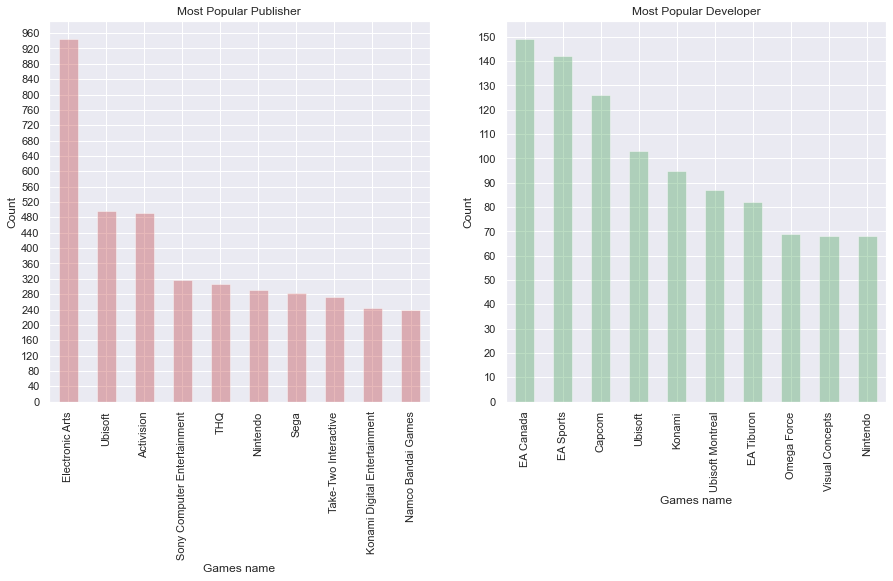

**INSIGHT-** The most Popular Publisher is Electronic Arts with 944 titles and the most Popular Developer is EA Canada with around 149 titles.

### 9. What is the impact of latest generations consoles on gaming titles ?

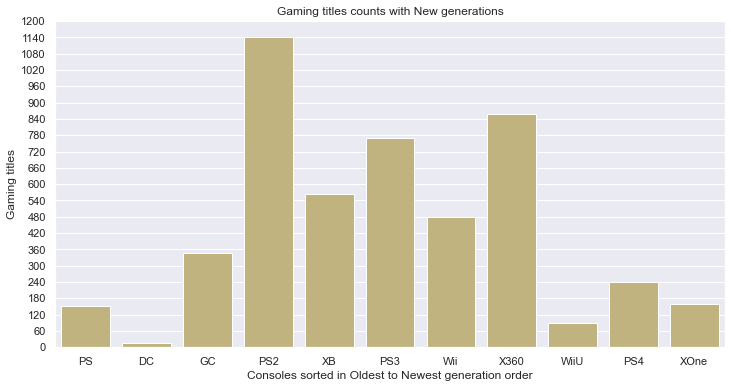

**INSIGHT-** Gaming titles, for popularity factor, are dependant on gaming consoles Success. But We can't forget that with most successful gaming consoles generation change, the title counts are affected too. Playstation was first and major revolutionary console of fifth generation consoles, The titles are less due to the lack of technology at that time. DS,GC,PS2 and XB are consoles of sixth generation. Talking about popularity of consoles,PS2 was most sold consoles of sixth generation. Coming to the seventh generation with platforms as PS3,Wii and X360, titles started to decrease, cause with new gen hardware customers were demanding something more appealing to the eyes i.e. better graphics. Coming to the eighth generation platforms as WiiU,PS4 and XOne, titles started to decrease more. Cause the features like Triple AAA buffering and high shaders were making it difficult to release games within short span of time.

### 10. What are the Top 10 games in terms of Critic Score ?

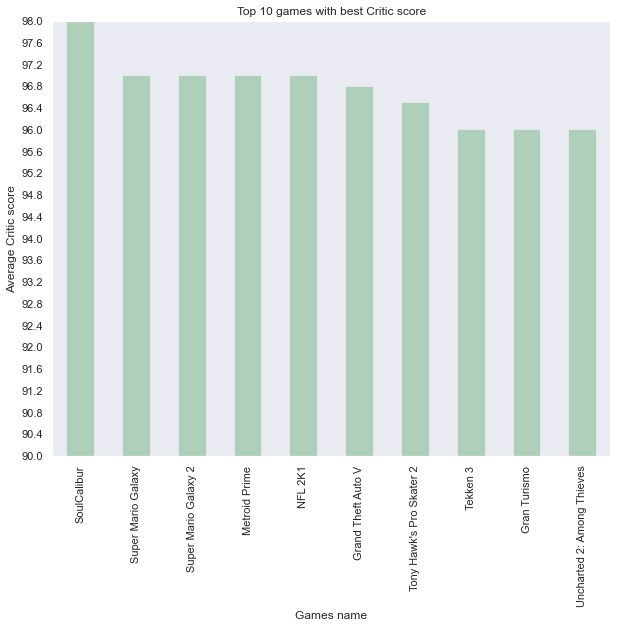

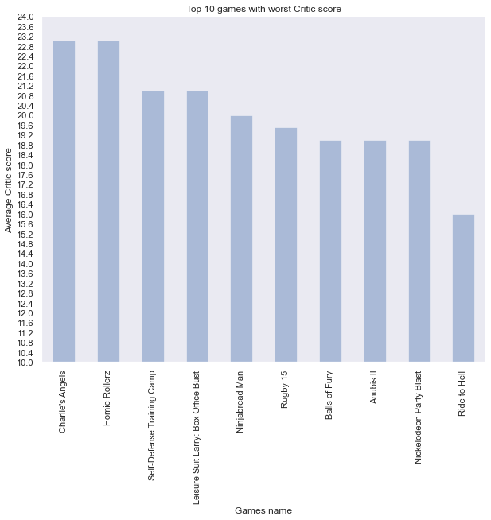

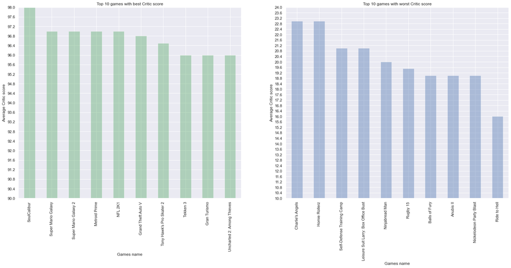

**INSIGHT-** I grouped the games in terms of Average Critics Score. Since there are 6825 titles in the whole dataset, It is quite difficult to Plot each one of them.

> For games with best critic Score:- I filtered only first Ten games instead of whole list. Also I trimmed the Y axis from 90 to 98.0, to help audience to grab little differences quite well. The Only reason for doing this was, that there were all the games in top 10 list whose critic score were above 90. As we can See here, 'Soul Calibur' is the game with Best Critic Score, A score of 98. 'Uncharted 2' comes on 10th Position with Critic Score of 96. Technically Saying,'Super Mario Galaxy', 'Super Mario Galaxy 2', 'Metroid Prime' and 'NFL2K1' they all are on second position with same Critic Score of 97.  
> For games with worst critic Score:- I also filtered only last Ten games instead of whole list. Also I trimmed Y axis from 10 to 24,cause last 10 of the games were between these. 'Ride to Hell' is the game least Scored with a Critic Score of 16 out of 100. 'Charlie's Angels' comes on 10th last with a Critic Score of 23.

### 11. What are the Top 10 games in terms of User Score ?

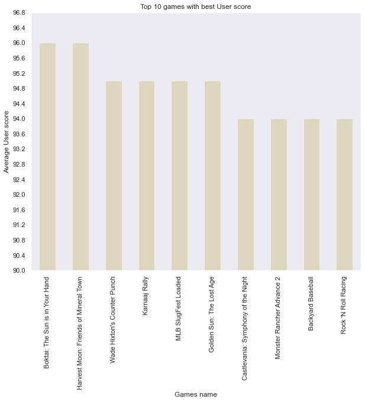

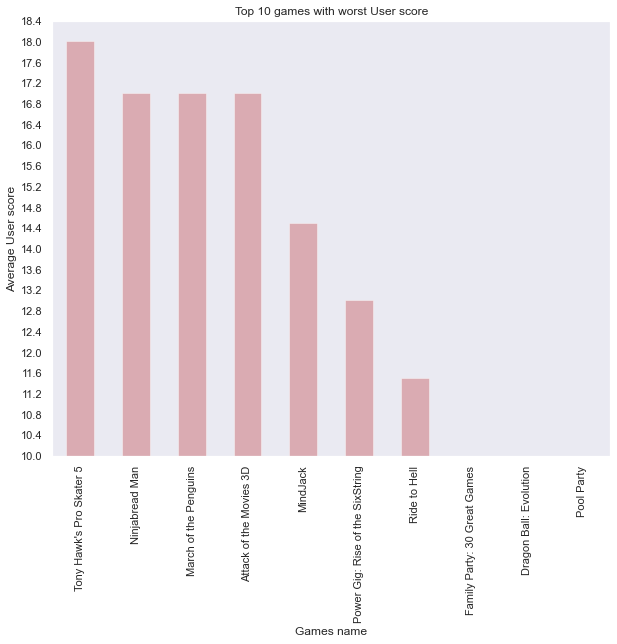

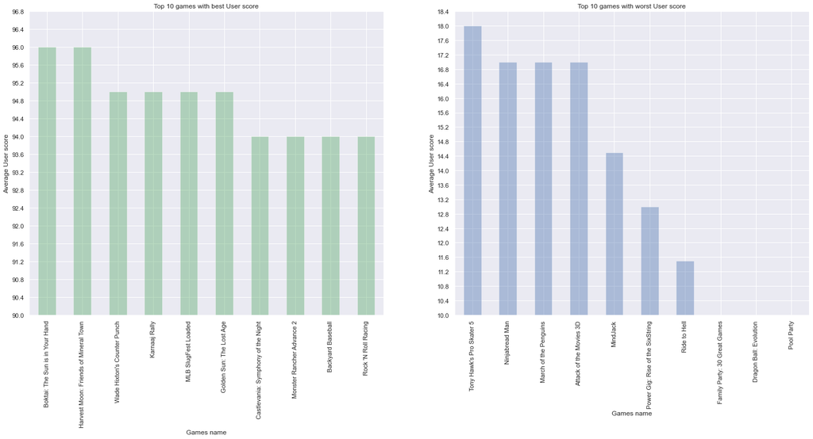

**INSIGHT-** I grouped the games in terms of Average User Score. Since there are 6825 titles in the whole dataset, It is quite difficult to Plot each one of them.

### 12. What is the Impact of Critic Score and User Score on Global Sales of video game Units?

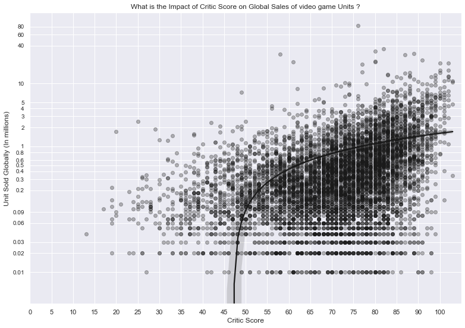

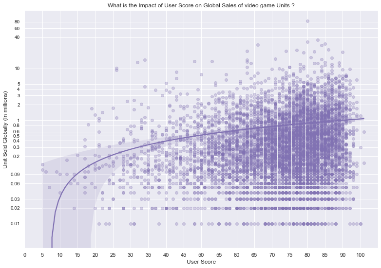

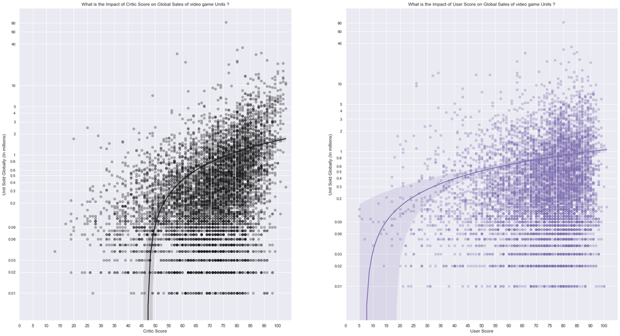

**INSIGHT-** As you can see, there was a need to transform the Global Sales axis with log trans. After doing so its looks pretty clean. The regression line is having a bent in both cases due to the log scale applied on Y axis. But we can see there is positive Co-relation between Critic Score:Global Sales and User Score:Global Sales. Though the relation is not strong enough, but still it clarifies that more the Critic Score or User Score of the game is, the more it is capable of selling units globally. I applied transparency parameter to see the overlapping of points at certain areas. The regression plot is more darker around 50-90 Critic Score & User Score for both the Cases, which defines that most of the games were having Score between these twos. The Critic Score regression Line is more rising with a better angle from 0.2 than User Score, which makes it a stronger relative than User Score. The intercept in both the cases is on X axis and it is starting after some points. The points from it starts indicates that relation is acually working from those points.

### 13. Does more Score counter means more Score ?

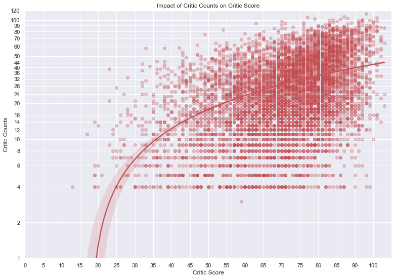

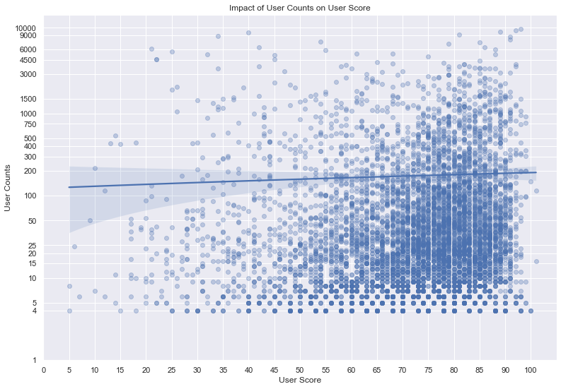

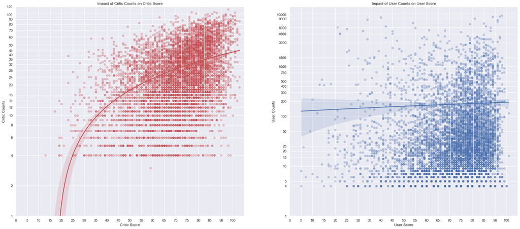

**INSIGHT-** Critic Score and counts relation was already clear,but we needed to work on User score relation with their counts.The work is now done.  
**(1) Impact of Critic Counts on Critic Score-** The relation here is quite transparent to see. More the Critic Counts, better the Critic Score is. However it raises the question that what if games with low Critic Score were reviewed by more Crtitic. How would have they scored then? The relation starts from the Critic Score of 20 and it is all positive.  
**(2) Impact of User Counts on User Score-** The relation here is Stable. Although there is a very little rise from approx 130 to 200 Critic Counts, but all rounder the relation is not negative nor positive. There is no impact of User counts on User Score. Even with the high counts of User Counts like 6000, User score is still between 20 and 25. That is the correct way of rating games.

### 14. Which rating metric is more popular for a specific genre game ?

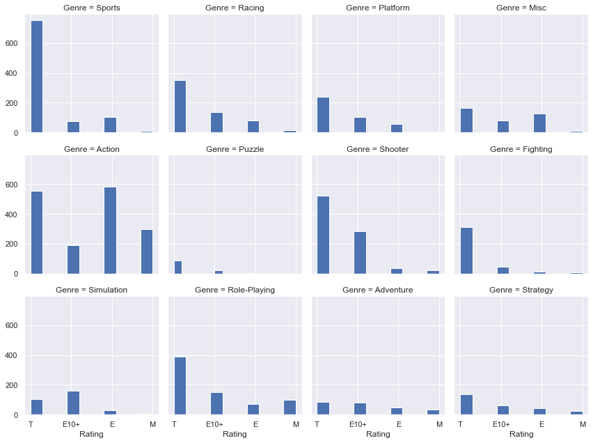

### 15. Which rating metric is more popular for a specific Platform ?

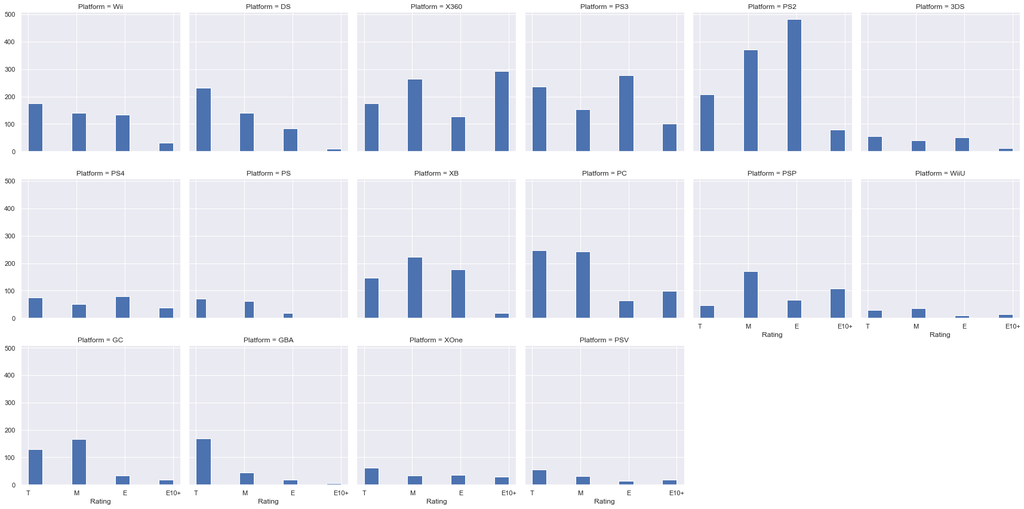

**INSIGHT-** Playstaion 2 was the platform with most 'M' and 'E' rated gaming titles. WiiU has overall least proportion of gaming titles, that's why every rating is lowest amongst all. More informative analysis can be performed on the basis of this facet graph.

### 16. Which of the Rating metric is critically acclaimed ?

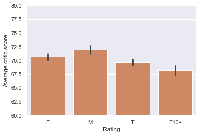

**INSIGHT-** Amongst all other metrics, Mature Rated titles have more Critic Score. With the Analysis, The conclusion is that mature rated titles recieve around an average Critic Score of 71.96. 'E' Rating comes on second with average Critic Score of 70.67 and 'T' comes on third with an average Critic Score of 69.67. 'E10+' Rating comes last with an average Critic Score of 68.22.

### 17. Which is the effect of Rating on Global Sales ?

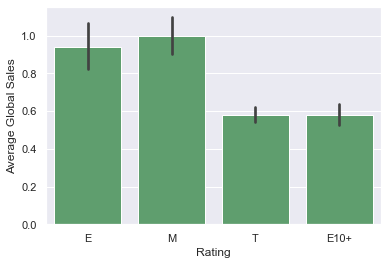

**INSIGHT-** It was shown previously that Critic Score and Global Sales has positive Relation. The same relational effect can be seen here. In terms of Critic Score, M rating was on top. Same thing is going on here i.e. M Rated titles are sold most with 994,962 copies, beating 'E' to the second with 941,162 copies, beating 'E10+' to third with 581,237 copies and 'T' to last with 579,436 copies sold worldwide.

### 18. Which Platform titles were most sold Globally ?

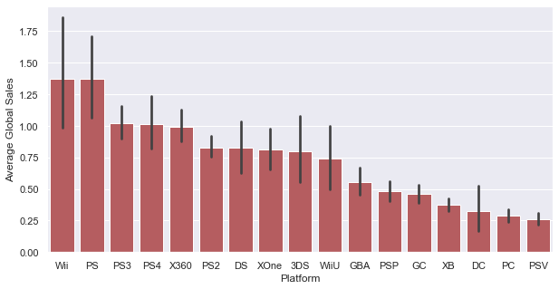

**INSIGHT-** Wii is the console with around 1,375,741 copies sold globally of their released titles. Playstation comes on second with around 1,373,356 copies sold globally of their released titles. Playstaion Vita comes on last with only 2,61,695 copies sold globally of their released titles.

### 19. Top 10 Publishers, whose games were sold most globally ?

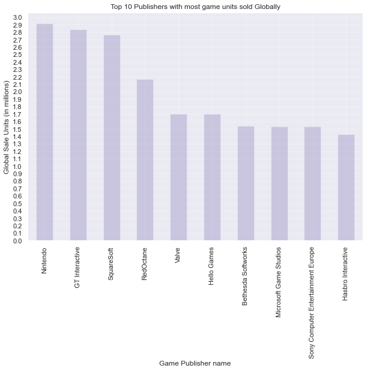

**INSIGHT-** Nintendo is the publisher which tops the best publisher chart with 2,919,210 copies sold globally of their published games. Rest of the data is highly informative.

### 20. Top 10 Developers, whose games were sold most globally ?

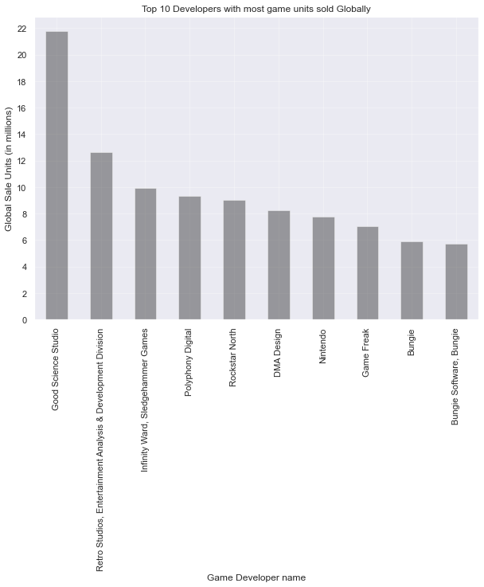

**INSIGHT-** Good Science Studios is the Studio and developer company which come on first with around 21,810,000 copies sold of the games they developed.

### 21. Does relation between Critic Score and Critic counts is affected by Year of Release?

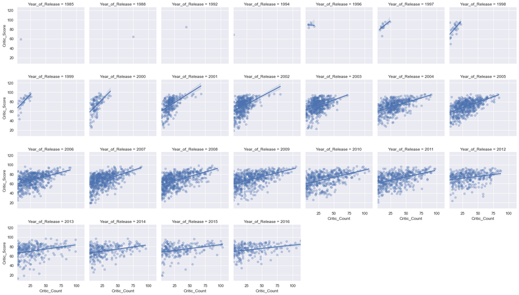

**INSIGHT-** The relation between Critic Score and Critic Counts is overall positive as shown previously. But as we progress through the year of release titles we can actually see the regression line going down angular. The curve is most rising with the games released in 1998 and after that, on an average, the regression line keeps on falling downwards. At the year 2016 we can almost see stable relation between both. Maybe we can say that people actually scored games on their quality, rather than their popularity. Scatter plots with year of release before 2000 are less denser due to the lesser titles released at that time. This plot actually assissted us in witnessing the big picture rather than just simply saying that, 'more the critic count, more the Critic score'.

### 22. Which Rating is more popular with global sales across different years of release?

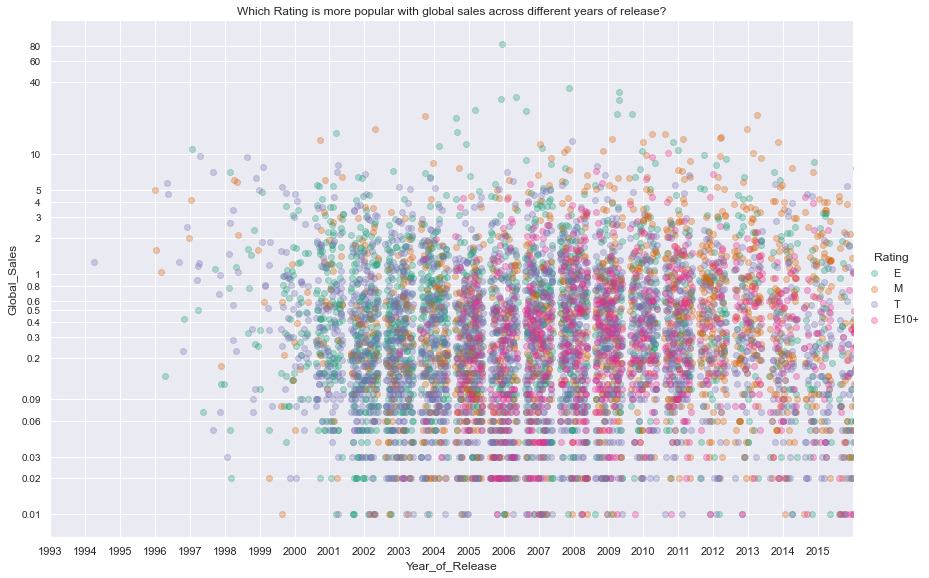

### 23. Which Platform released title Ratings were scored best ?

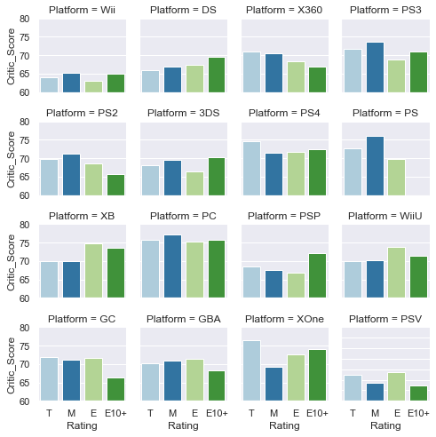

### 24. Which genre Rating is scored best ?

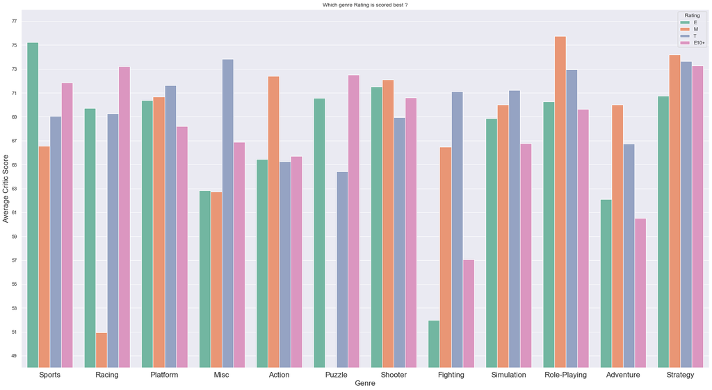